# Akula-DATA606-Week02-Homework

Pavan Akula

February 11, 2017

Libraries used

```r
#install.packages('VennDiagram')
#install.packages('pander')

library(grid)
library(futile.logger)
library(VennDiagram)
library(knitr)
```

Practice Questions:

Q 1: (2.5) Coin flips. If you flip a fair coin 10 times, what is the probability of

1. getting all tails?
2. getting all heads?
3. getting at least one tails?

A: Probability of fair coin landing *heads or tails is 50%*. And event is mutually exclusive, each coin flip will land hear or tail.

Q 2: (2.7) Swing voters. A 2012 Pew Research survey asked 2,373 randomly sampled registered voters their political affiliation (Republican, Democrat, or Independent) and whether or not they identify as swing voters. 35% of respondents identified as Independent, 23% identified as swing voters, and 11% identified as both.

1. Are being Independent and being a swing voter disjoint, i.e. mutually exclusive?
2. Draw a Venn diagram summarizing the variables and their associated probabilities.
3. What percent of voters are Independent but not swing voters?
4. What percent of voters are Independent or swing voters?
5. What percent of voters are neither Independent nor swing voters?
6. Is the event that someone is a swing voter independent of the event that someone is a political Independent

```r
# 11% of 2373 are swing and independent
# round((2372*.23) - 2373*11) are swing and non independent
# round((2372*.35) - (2373*11)) are non swing and indenpendent
# (2373 - (round(2373*11) + round((2372*.23) - 2373*11) + round((2372*.35) - 2373*11))) are non swing and non independent

voter.data <- matrix(c(round(2373*.11), round((2372*.23) - 2373*.11), round((2372*.35) - (2373*.11)), (2373 - (round(2373*.11) + round((2372*.23) - 2373*.11) + round((2372*.35) - 2373*.11)))),ncol=2,byrow=TRUE)

# calculate percent for swing and independent, swing and non independent, swing and non independent, non swing and indenpendent
voter.data.percentages <- round((voter.data/2373),2)

# Attach column and row names
colnames(voter.data)<- c("Independent:Yes","Independent:No")
rownames(voter.data)<- c("Swing:Yes","Swing:No")

# Attach column and row names for percent also
colnames(voter.data.percentages)<- c("Independent:Yes","Independent:No")
rownames(voter.data.percentages)<- c("Swing:Yes","Swing:No")

# Calculate row and column sums
voter.data <- cbind(voter.data, Total = rowSums(voter.data))
voter.data <- rbind(voter.data, Total = colSums(voter.data))

# Calculate row and column sums
voter.data.percentages <- cbind(voter.data.percentages, Total = rowSums(voter.data.percentages))
voter.data.percentages <- rbind(voter.data.percentages, Total = colSums(voter.data.percentages))
```

```r
voter.data
```

```
##           Independent:Yes Independent:No Total
## Swing:Yes             261            285   546
## Swing:No              569           1258  1827
## Total                 830           1543  2373
```

```r
voter.data.percentages
```

```
##           Independent:Yes Independent:No Total
## Swing:Yes            0.11           0.12  0.23
## Swing:No             0.24           0.53  0.77
## Total                0.35           0.65  1.00
```

(b), (c), (d), (e)

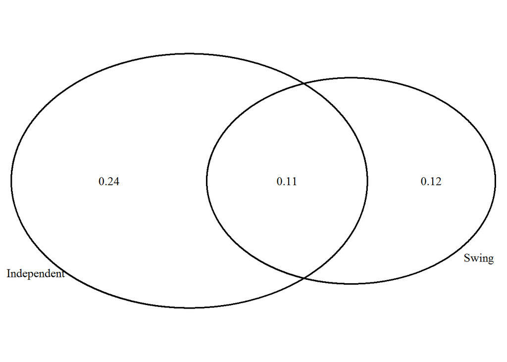

```
## (polygon[GRID.polygon.1], polygon[GRID.polygon.2], polygon[GRID.polygon.3], polygon[GRID.polygon.4], text[GRID.text.5], text[GRID.text.6], text[GRID.text.7], text[GRID.text.8], text[GRID.text.9])
```

```r
# Percent of voters that are Idependent (no party affiliation) and decided whom to vote (Non Swing) : 0.24
# Percent of voters that are Idependent (no party affiliation) and not yet decided whom to vote (Swing) : 0.11
# Percent of voters that are Non Idependent (has party affiliation) and not yet decided whom to (Swing) : 0.12
# Percent of voters that are Non Idependent (has party affiliation) and decided whom to vote (Non Swing) : 0.53

grid.newpage()
# Venn diagram for Swing and Independent
draw.pairwise.venn(area1 = voter.data.percentages[1,3], area2 = voter.data.percentages[3,1], cross.area = voter.data.percentages[1,1], category = c("Swing","Independent"))
```

1. Are being female and liking Five Guys Burgers mutually exclusive?
2. What is the probability that a randomly chosen male likes In-N-Out the best?
3. What is the probability that a randomly chosen female likes In-N-Out the best?
4. What is the probability that a man and a woman who are dating both like In-N-Out the best? Note any assumption you make and evaluate whether you think that assumption is reasonable.
5. What is the probability that a randomly chosen person likes Umami best or that person is female?

A: (a) Yes. Being female and liking Five Guys Burger is mutually exclusive (b) Of 248 total males 162 like In-N-Out. Probability of liking is *162*100/248 = 65.32%* (c) Of 252 total males 181 like In-N-Out. Probability of liking is *181*100/252 = 71.83%* (d) Probability of men liking In-N-Out is *0.6532* and women liking In-N-Out *0.7183*. In this case picking of second person is dependent on first person. First person being man or woman probability is 0.5. But if first person is man then second person has to be woman. And if first person is woman then second person has to be man. With assumptions probability of liking In-N-Out by man and woman who are dating is *(0.6532*0.7183)*(0.5+0.5) = 0.4692*. There is 46.92 percent chance that man and woman who are dating will like In-N-Out. (e) Of 500 people 6 like Umami Probability of liking is *6/500 = 0.012*. Probability of being female is *252/500 = 0.504*. There is one case were female liking Umami. Probability of that person being selected is *1/500 = 0.002*. Since that person counted twice in female and Umami population it needs to subtracted. Probability of liking Umami or female is *0.012 + 0.504 - 0.002 = 0.514*

Q 4: (2.29) Chips in a bag. Imagine you have a bag containing 5 red, 3 blue, and 2 orange chips.

1. Suppose you draw a chip and it is blue. If drawing without replacement, what is the probability the next is also blue?
2. Suppose you draw a chip and it is orange, and then you draw a second chip without replacement. What is the probability this second chip is blue?
3. If drawing without replacement, what is the probability of drawing two blue chips in a row?
4. When drawing without replacement, are the draws independent? Explain.

A: (a) Total chips = *5 + 3 + 2 = 10*. Probability of drawing blue on first draw = *3/10*. Since chip is not replaced probability of second event = *2/9*. Probability of getting blue both times = *(3/10)*(2/9) = 1/15 = 6.67%* (b) On the second draw total chips = *5 + 3 + 1 = 9*. Probability of drawing blue = *3/9 = 1/3 = 33.33%* (c) *3/10*2/9 = 6.67%* (d) Drawing without replacement is independent. It is called dependent probability.

1. What fraction of these cats weigh less than 2.5 kg?
2. What fraction of these cats weigh between 2.5 and 2.75 kg?
3. What fraction of these cats weigh between 2.75 and 3.5 kg?

A: (a) (30 + 33)/Total cats = 63/144 (b) (20 + 27)/Total cats = 47/144 (c) (15 + 12)/Total cats = 27/144

Graded Questions

Q 1: (2.6) Dice rolls. If you roll a pair of fair dice, what is the probability of

1. getting a sum of 1?
2. getting a sum of 5?
3. getting a sum of 12?

A: (a) *Zero*. Because fair dice has a minimum value of 1. Hence sum cannot be equal to 1. (b) Sum of 5 can happen multiple ways. *1+4, 2+3, 3+2, 4+1*. Hence probability of getting 5 is *4/36*. (c) Sum of 12 can happen only one way. *6+6*. Hence probability of getting 12 is *1/36*.

Q 2: (2.8) Poverty and language. The American Community Survey is an ongoing survey that provides data every year to give communities the current information they need to plan investments and services. The 2010 American Community Survey estimates that 14.6% of Americans live below the poverty line, 20.7% speak a language other than English (foreign language) at home, and 4.2% fall into both categories.

1. Are living below the poverty line and speaking a foreign language at home disjoint?
2. Draw a Venn diagram summarizing the variables and their associated probabilities.
3. What percent of Americans live below the poverty line and only speak English at home?
4. What percent of Americans live below the poverty line or speak a foreign language at home?
5. What percent of Americans live above the poverty line and only speak English at home?
6. Is the event that someone lives below the poverty line independent of the event that the person speaks a foreign language at home

```r
# 14.6% of population live below Poverty (0.146 percent)
# 20.7% speak No English (0.207 percent)
# 4.2% fall into both categories, speak No English and live below the poverty line (0.042 percent)
# Percent speak No English and live above poverty line = *(0.207 - 0.042)*
# Percent living above poverty line *(1 - 0.146)*
# Percent speaking English (1 - 0.207)
# Percent speaking English and live above poverty line = *Percent living above poverty line - Percent speak No English and live above poverty line*

population.data <- matrix(c(round((0.146-0.042),3), round((1-0.207-(0.146-0.042)),3), round(0.042,3), (round((0.207-0.042),3))),ncol=2,byrow=TRUE)

# Attach column and row names
colnames(population.data)<- c("Poverty:Yes","Poverty:No")
rownames(population.data)<- c("English:Yes","English:No")

# Calculate row and column sums
population.data <- cbind(population.data, Total = rowSums(population.data))
population.data <- rbind(population.data, Total = colSums(population.data))
```

```r
population.data
```

```
##             Poverty:Yes Poverty:No Total
## English:Yes       0.104      0.689 0.793
## English:No        0.042      0.165 0.207
## Total             0.146      0.854 1.000
```

[output not shown]

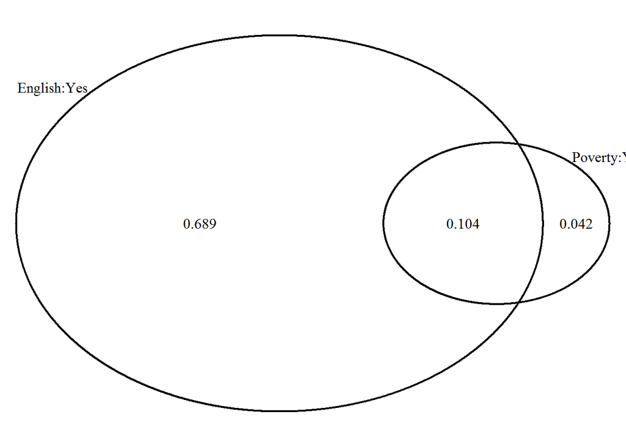

```
## (polygon[GRID.polygon.10], polygon[GRID.polygon.11], polygon[GRID.polygon.12], polygon[GRID.polygon.13], text[GRID.text.14], text[GRID.text.15], text[GRID.text.16], text[GRID.text.17], text[GRID.text.18])
```

```r
# Percent of population living above the Poverty line and speaking a English language : 0.689
# Percent of population living below the Poverty line and speaking a English language : 0.104
# Percent of population living below the Poverty line and speaking a No English language : 0.042
# Percent of population living above the Poverty line and speaking a No English language : 0.165

grid.newpage()
# Venn diagram for Swing and Independent
draw.pairwise.venn(area1 = population.data[1,3], area2 = population.data[3,1], cross.area = population.data[1,1], category = c("English:Yes","Poverty:Yes"))
```

1. What is the probability that a randomly chosen male respondent or his partner has blue eyes?
2. What is the probability that a randomly chosen male respondent with blue eyes has a partner with blue eyes?
3. What is the probability that a randomly chosen male respondent with brown eyes has a partner with blue eyes? What about the probability of a randomly chosen male respondent with green eyes having a partner with blue eyes?
4. Does it appear that the eye colors of male respondents and their partners are independent? Explain your reasoning.

Q 4: (2.30) Books on a bookshelf. The table below shows the distribution of books on a bookcase based on whether they are nonfiction or fiction and hardcover or paperback.

1. Find the probability of drawing a hardcover book first then a paperback fiction book second when drawing without replacement.
2. Determine the probability of drawing a fiction book first and then a hardcover book second, when drawing without replacement.
3. Calculate the probability of the scenario in part (b), except this time complete the calculations under the scenario where the first book is placed back on the bookcase before randomly drawing the second book.
4. The final answers to parts (b) and (c) are very similar. Explain why this is the case.

Book data

```r
book.data <- matrix(c(13, 59, 15, 8),ncol=2,byrow=TRUE)

# Attach column and row names
colnames(book.data)<- c("Format:Hardcover","Format:Paperback")
rownames(book.data)<- c("Type:Fiction","Type:Nonfiction")

# Calculate row and column sums
book.data <- cbind(book.data, Total = rowSums(book.data))
book.data <- rbind(book.data, Total = colSums(book.data))

book.data
```

```
##                 Format:Hardcover Format:Paperback Total
## Type:Fiction                  13               59    72
## Type:Nonfiction               15                8    23
## Total                         28               67    95
```

Q: 5: (2.38) Baggage fees. An airline charges the following baggage fees: $25 for the first bag and $35 for the second. Suppose 54% of passengers have no checked luggage, 34% have one piece of checked luggage and 12% have two pieces. We suppose a negligible portion of people check more than two bags.

1. Build a probability model, compute the average revenue per passenger, and compute the corresponding standard deviation.
2. About how much revenue should the airline expect for a flight of 120 passengers? With what standard deviation? Note any assumptions you make and if you think they are justified.

A: (a) Lets assume there will be *n* number of passengers. No fees is collected if zero bags are checked in, 1 bag $25 and 2 bags $60($25 + $35)

Number of passengers with *zero* bags checked = n*0.54

Number of passengers with *one* bags checked = n*0.34

Number of passengers with *two* bags checked = n*0.12

Fees collected from passengers with *zero* bags checked = n*0.54*0

Fees collected from passengers with *one* bags checked = n*0.34*25

Fees collected from passengers with *one* bags checked = n*0.12*60

Standard deviation,  
1. Calculate difference in revenues per passenger based on mean(average m) (((n*[percentage of bag checkers]*0) - m) for each percentage class(0.54, 0.34, 0.12)

2. Calculate square for each above values as (((n*[percentage of bag chekers]*0) - m)<sup>2</sup> for each percentage class(0.54, 0.34, 0.12)
3. Multiple values from step 2 with baggage checker percentages (((n*[percentage of bag chekers]*0) - m)<sup>2</sup> * [percentage of bag chekers]
4. Sum all the values from step 3 and find the square root to get standard deviation.

```r
#Total Passangers = 120
passengers.data <- matrix(c(round(120 * 0.54), 0.54, 0, 0, round(120 * 0.34), 0.34, 1, 25, round(120 * 0.12), 0.12, 2, 25+35),ncol=4,byrow=TRUE)

# Attach column and row names
colnames(passengers.data)<- c("Passengers","Percentage","NumberOfBags","Fees")

# Total fees collected
passengers.data <- cbind(passengers.data, TotalFeesCollected = passengers.data[,1] * passengers.data[,4])

# Create a table
passenger.table <- data.frame(passengers.data)

#Average fee
totalRevenuePerPassanger <- sum(passenger.table$TotalFeesCollected) / 120 #Average fee

#Calculate difference in fee from average
passenger.table$DiffInFee <- passenger.table$Fees - totalRevenuePerPassanger

#Square the difference
passenger.table$SqDiff <- passenger.table$DiffInFee^2

#Calulate weighed difference fo squared value
passenger.table$WtDiff <- passenger.table$SqDiff * passenger.table$Percentage

#Get sum of weighted differences. Also known as variance
sumWtDiff <- sum(passenger.table$WtDiff)

#Standard deviation
sdValue <- sqrt(sumWtDiff)
```

Total revenues : $1865

Average revenue per passenger : $15.54

Standard deviation : $20

1. Describe the distribution of total personal income.
2. What is the probability that a randomly chosen US resident makes less than $50,000 per year?
3. What is the probability that a randomly chosen US resident makes less than$50,000 per year and is female? Note any assumptions you make.
4. The same data source indicates that 71.8% of females make less than $50,000 per year. Use this value to determine whether or not the assumption you made in part (c) is valid.